# Risk Factor Analysis

## Outcome Variable

**Outcome Variable:** ever_wasted

## Predictor Variables

**Intervention Variable:** predexfd6

**Adjustment Set:**

- arm
- sex
- brthmon
- W_mage
- meducyrs
- feducyrs
- hhwealth_quart
- hfoodsec
- W_mhtcm
- W_mwtkg
- W_mbmi
- vagbrth
- W_gagebrth
- W_birthwt
- W_birthlen
- W_nrooms
- W_nchldlt5
- month
- W_parity
- impfloor
- impsan
- safeh20
- delta_W_mage
- delta_meducyrs
- delta_feducyrs
- delta_hhwealth_quart
- delta_hfoodsec
- delta_W_mhtcm
- delta_W_mwtkg
- delta_W_mbmi
- delta_vagbrth
- delta_W_gagebrth
- delta_W_birthwt
- delta_W_birthlen
- delta_W_nrooms
- delta_W_nchldlt5
- delta_month
- delta_W_parity
- delta_impfloor
- delta_impsan
- delta_safeh20

## Stratifying Variables

The analysis was stratified on these variable(s):

- agecat
- studyid
- country

## Data Summary

| agecat | studyid | country | predexfd6 | ever_wasted | n_cell | n |
| --- | --- | --- | --- | --- | --- | --- |
| 0-24 months (no birth wast) | CMC-V-BCS-2002 | INDIA | 1 | 0 | 11 | 19 |
| 0-24 months (no birth wast) | CMC-V-BCS-2002 | INDIA | 1 | 1 | 8 | 19 |
| 0-24 months (no birth wast) | CMC-V-BCS-2002 | INDIA | 0 | 0 | 0 | 19 |
| 0-24 months (no birth wast) | CMC-V-BCS-2002 | INDIA | 0 | 1 | 0 | 19 |
| 0-24 months (no birth wast) | EE | PAKISTAN | 1 | 0 | 21 | 48 |
| 0-24 months (no birth wast) | EE | PAKISTAN | 1 | 1 | 22 | 48 |
| 0-24 months (no birth wast) | EE | PAKISTAN | 0 | 0 | 3 | 48 |
| 0-24 months (no birth wast) | EE | PAKISTAN | 0 | 1 | 2 | 48 |
| 0-24 months (no birth wast) | GMS-Nepal | NEPAL | 1 | 0 | 176 | 560 |
| 0-24 months (no birth wast) | GMS-Nepal | NEPAL | 1 | 1 | 241 | 560 |
| 0-24 months (no birth wast) | GMS-Nepal | NEPAL | 0 | 0 | 66 | 560 |
| 0-24 months (no birth wast) | GMS-Nepal | NEPAL | 0 | 1 | 77 | 560 |
| 0-24 months (no birth wast) | IRC | INDIA | 1 | 0 | 0 | 14 |
| 0-24 months (no birth wast) | IRC | INDIA | 1 | 1 | 0 | 14 |
| 0-24 months (no birth wast) | IRC | INDIA | 0 | 0 | 5 | 14 |
| 0-24 months (no birth wast) | IRC | INDIA | 0 | 1 | 9 | 14 |
| 0-24 months (no birth wast) | JiVitA-3 | BANGLADESH | 1 | 0 | 10160 | 15666 |
| 0-24 months (no birth wast) | JiVitA-3 | BANGLADESH | 1 | 1 | 2046 | 15666 |
| 0-24 months (no birth wast) | JiVitA-3 | BANGLADESH | 0 | 0 | 2829 | 15666 |
| 0-24 months (no birth wast) | JiVitA-3 | BANGLADESH | 0 | 1 | 631 | 15666 |
| 0-24 months (no birth wast) | JiVitA-4 | BANGLADESH | 1 | 0 | 2753 | 4722 |
| 0-24 months (no birth wast) | JiVitA-4 | BANGLADESH | 1 | 1 | 927 | 4722 |
| 0-24 months (no birth wast) | JiVitA-4 | BANGLADESH | 0 | 0 | 736 | 4722 |
| 0-24 months (no birth wast) | JiVitA-4 | BANGLADESH | 0 | 1 | 306 | 4722 |
| 0-24 months (no birth wast) | Keneba | GAMBIA | 1 | 0 | 543 | 2226 |
| 0-24 months (no birth wast) | Keneba | GAMBIA | 1 | 1 | 280 | 2226 |
| 0-24 months (no birth wast) | Keneba | GAMBIA | 0 | 0 | 822 | 2226 |
| 0-24 months (no birth wast) | Keneba | GAMBIA | 0 | 1 | 581 | 2226 |
| 0-24 months (no birth wast) | LCNI-5 | MALAWI | 1 | 0 | 42 | 271 |
| 0-24 months (no birth wast) | LCNI-5 | MALAWI | 1 | 1 | 5 | 271 |

[output cut: 186 more lines]

The following strata were considered:

- agecat: 0-24 months (no birth wast), studyid: CMC-V-BCS-2002, country: INDIA
- agecat: 0-24 months (no birth wast), studyid: EE, country: PAKISTAN
- agecat: 0-24 months (no birth wast), studyid: GMS-Nepal, country: NEPAL
- agecat: 0-24 months (no birth wast), studyid: IRC, country: INDIA
- agecat: 0-24 months (no birth wast), studyid: JiVitA-3, country: BANGLADESH
- agecat: 0-24 months (no birth wast), studyid: JiVitA-4, country: BANGLADESH
- agecat: 0-24 months (no birth wast), studyid: Keneba, country: GAMBIA
- agecat: 0-24 months (no birth wast), studyid: LCNI-5, country: MALAWI
- agecat: 0-24 months (no birth wast), studyid: MAL-ED, country: BANGLADESH
- agecat: 0-24 months (no birth wast), studyid: MAL-ED, country: BRAZIL
- agecat: 0-24 months (no birth wast), studyid: MAL-ED, country: INDIA
- agecat: 0-24 months (no birth wast), studyid: MAL-ED, country: NEPAL
- agecat: 0-24 months (no birth wast), studyid: MAL-ED, country: PERU
- agecat: 0-24 months (no birth wast), studyid: MAL-ED, country: SOUTH AFRICA
- agecat: 0-24 months (no birth wast), studyid: MAL-ED, country: TANZANIA, UNITED REPUBLIC OF
- agecat: 0-24 months (no birth wast), studyid: PROVIDE, country: BANGLADESH
- agecat: 0-24 months (no birth wast), studyid: SAS-CompFeed, country: INDIA
- agecat: 0-24 months (no birth wast), studyid: SAS-FoodSuppl, country: INDIA
- agecat: 0-6 months (no birth wast), studyid: CMC-V-BCS-2002, country: INDIA
- agecat: 0-6 months (no birth wast), studyid: EE, country: PAKISTAN
- agecat: 0-6 months (no birth wast), studyid: GMS-Nepal, country: NEPAL
- agecat: 0-6 months (no birth wast), studyid: IRC, country: INDIA
- agecat: 0-6 months (no birth wast), studyid: JiVitA-3, country: BANGLADESH
- agecat: 0-6 months (no birth wast), studyid: JiVitA-4, country: BANGLADESH
- agecat: 0-6 months (no birth wast), studyid: Keneba, country: GAMBIA
- agecat: 0-6 months (no birth wast), studyid: LCNI-5, country: MALAWI
- agecat: 0-6 months (no birth wast), studyid: MAL-ED, country: BANGLADESH
- agecat: 0-6 months (no birth wast), studyid: MAL-ED, country: BRAZIL
- agecat: 0-6 months (no birth wast), studyid: MAL-ED, country: INDIA
- agecat: 0-6 months (no birth wast), studyid: MAL-ED, country: NEPAL
- agecat: 0-6 months (no birth wast), studyid: MAL-ED, country: PERU
- agecat: 0-6 months (no birth wast), studyid: MAL-ED, country: SOUTH AFRICA
- agecat: 0-6 months (no birth wast), studyid: MAL-ED, country: TANZANIA, UNITED REPUBLIC OF
- agecat: 0-6 months (no birth wast), studyid: PROVIDE, country: BANGLADESH
- agecat: 0-6 months (no birth wast), studyid: SAS-CompFeed, country: INDIA
- agecat: 0-6 months (no birth wast), studyid: SAS-FoodSuppl, country: INDIA
- agecat: 6-24 months, studyid: CMC-V-BCS-2002, country: INDIA
- agecat: 6-24 months, studyid: EE, country: PAKISTAN
- agecat: 6-24 months, studyid: GMS-Nepal, country: NEPAL
- agecat: 6-24 months, studyid: IRC, country: INDIA
- agecat: 6-24 months, studyid: JiVitA-3, country: BANGLADESH
- agecat: 6-24 months, studyid: JiVitA-4, country: BANGLADESH
- agecat: 6-24 months, studyid: Keneba, country: GAMBIA
- agecat: 6-24 months, studyid: LCNI-5, country: MALAWI
- agecat: 6-24 months, studyid: MAL-ED, country: BANGLADESH
- agecat: 6-24 months, studyid: MAL-ED, country: BRAZIL
- agecat: 6-24 months, studyid: MAL-ED, country: INDIA
- agecat: 6-24 months, studyid: MAL-ED, country: NEPAL
- agecat: 6-24 months, studyid: MAL-ED, country: PERU
- agecat: 6-24 months, studyid: MAL-ED, country: SOUTH AFRICA
- agecat: 6-24 months, studyid: MAL-ED, country: TANZANIA, UNITED REPUBLIC OF
- agecat: 6-24 months, studyid: PROVIDE, country: BANGLADESH
- agecat: 6-24 months, studyid: SAS-CompFeed, country: INDIA
- agecat: 6-24 months, studyid: SAS-FoodSuppl, country: INDIA

### Dropped Strata

Some strata were dropped due to rare outcomes:

- agecat: 0-24 months (no birth wast), studyid: CMC-V-BCS-2002, country: INDIA
- agecat: 0-24 months (no birth wast), studyid: EE, country: PAKISTAN
- agecat: 0-24 months (no birth wast), studyid: IRC, country: INDIA
- agecat: 0-24 months (no birth wast), studyid: MAL-ED, country: BRAZIL
- agecat: 0-24 months (no birth wast), studyid: MAL-ED, country: INDIA
- agecat: 0-24 months (no birth wast), studyid: MAL-ED, country: NEPAL
- agecat: 0-24 months (no birth wast), studyid: MAL-ED, country: SOUTH AFRICA
- agecat: 0-24 months (no birth wast), studyid: MAL-ED, country: TANZANIA, UNITED REPUBLIC OF
- agecat: 0-24 months (no birth wast), studyid: SAS-FoodSuppl, country: INDIA
- agecat: 0-6 months (no birth wast), studyid: CMC-V-BCS-2002, country: INDIA
- agecat: 0-6 months (no birth wast), studyid: EE, country: PAKISTAN
- agecat: 0-6 months (no birth wast), studyid: IRC, country: INDIA
- agecat: 0-6 months (no birth wast), studyid: LCNI-5, country: MALAWI
- agecat: 0-6 months (no birth wast), studyid: MAL-ED, country: BRAZIL
- agecat: 0-6 months (no birth wast), studyid: MAL-ED, country: INDIA
- agecat: 0-6 months (no birth wast), studyid: MAL-ED, country: NEPAL
- agecat: 0-6 months (no birth wast), studyid: MAL-ED, country: PERU
- agecat: 0-6 months (no birth wast), studyid: MAL-ED, country: SOUTH AFRICA
- agecat: 0-6 months (no birth wast), studyid: MAL-ED, country: TANZANIA, UNITED REPUBLIC OF
- agecat: 0-6 months (no birth wast), studyid: SAS-FoodSuppl, country: INDIA
- agecat: 6-24 months, studyid: CMC-V-BCS-2002, country: INDIA
- agecat: 6-24 months, studyid: EE, country: PAKISTAN
- agecat: 6-24 months, studyid: IRC, country: INDIA
- agecat: 6-24 months, studyid: MAL-ED, country: BRAZIL
- agecat: 6-24 months, studyid: MAL-ED, country: INDIA
- agecat: 6-24 months, studyid: MAL-ED, country: NEPAL
- agecat: 6-24 months, studyid: MAL-ED, country: PERU
- agecat: 6-24 months, studyid: MAL-ED, country: SOUTH AFRICA
- agecat: 6-24 months, studyid: MAL-ED, country: TANZANIA, UNITED REPUBLIC OF
- agecat: 6-24 months, studyid: SAS-FoodSuppl, country: INDIA

## Methods Detail

We’re interested in the causal parameters $E[Y_a]$ for all values of $a \in \mathcal{A}$. These parameters represent the mean outcome if, possibly contrary to fact, we intervened to set all units to have $A=a$. Under the randomization and positivity assumptions, these are identified by the statistical parameters $\psi_a=E_W[E_{Y|A,W}(Y|A=a,W)]$. In addition, we’re interested in the mean of $Y$, $E[Y]$ under no intervention (the observed mean). We will estimate these parameters by using SuperLearner to fit the relevant likelihood factors – $E_{Y|A,W}(Y|A=a,W)$ and $p(A=a|W)$, and then updating our likelihood fit using a joint TMLE.

For unadjusted analyses ($W=\{\}$), initial likelihoods were estimated using Lrnr_glm to estimate the simple $E(Y|A)$ and Lrnr_mean to estimate $p(A)$. For adjusted analyses, a small library containing Lrnr_glmnet, Lrnr_xgboost, and Lrnr_mean was used.

Having estimated these parameters, we will then use the delta method to estimate relative risks and attributable risks relative to a prespecified baseline level of $A$.

# Results Detail

## Results Plots

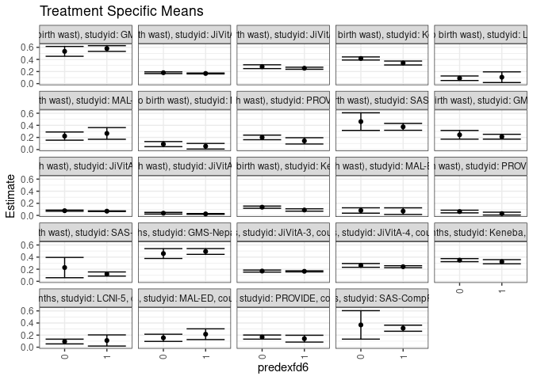

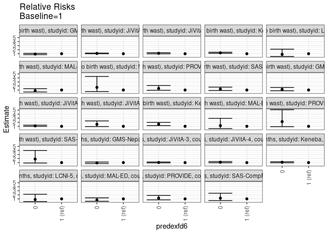

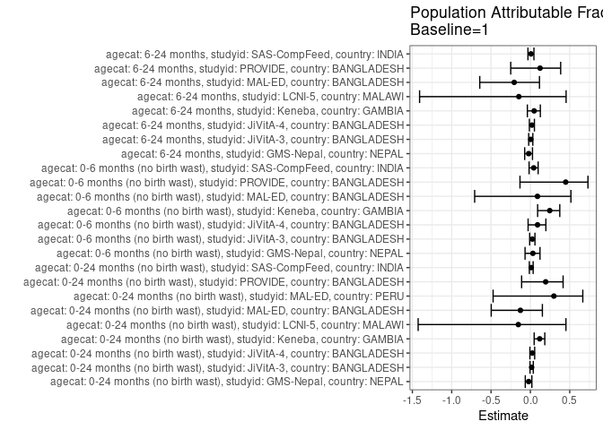

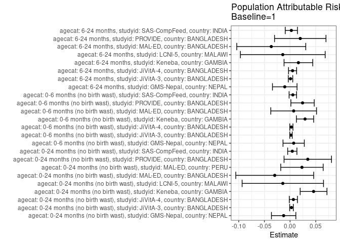

## Results Table

### Parameter: TSM

| agecat | studyid | country | intervention_level | baseline_level | estimate | ci_lower | ci_upper |
| --- | --- | --- | --- | --- | --- | --- | --- |
| 0-24 months (no birth wast) | GMS-Nepal | NEPAL | 1 | NA | 0.5803923 | 0.5332349 | 0.6275498 |
| 0-24 months (no birth wast) | GMS-Nepal | NEPAL | 0 | NA | 0.5335187 | 0.4521253 | 0.6149122 |
| 0-24 months (no birth wast) | JiVitA-3 | BANGLADESH | 1 | NA | 0.1681226 | 0.1609668 | 0.1752784 |
| 0-24 months (no birth wast) | JiVitA-3 | BANGLADESH | 0 | NA | 0.1805361 | 0.1663081 | 0.1947641 |
| 0-24 months (no birth wast) | JiVitA-4 | BANGLADESH | 1 | NA | 0.2546829 | 0.2378437 | 0.2715221 |
| 0-24 months (no birth wast) | JiVitA-4 | BANGLADESH | 0 | NA | 0.2801821 | 0.2490054 | 0.3113587 |
| 0-24 months (no birth wast) | Keneba | GAMBIA | 1 | NA | 0.3410216 | 0.3085716 | 0.3734717 |
| 0-24 months (no birth wast) | Keneba | GAMBIA | 0 | NA | 0.4157417 | 0.3901139 | 0.4413694 |
| 0-24 months (no birth wast) | LCNI-5 | MALAWI | 1 | NA | 0.1063830 | 0.0180722 | 0.1946938 |
| 0-24 months (no birth wast) | LCNI-5 | MALAWI | 0 | NA | 0.0892857 | 0.0518739 | 0.1266975 |
| 0-24 months (no birth wast) | MAL-ED | BANGLADESH | 1 | NA | 0.2659426 | 0.1693434 | 0.3625418 |
| 0-24 months (no birth wast) | MAL-ED | BANGLADESH | 0 | NA | 0.2221824 | 0.1546378 | 0.2897269 |
| 0-24 months (no birth wast) | MAL-ED | PERU | 1 | NA | 0.0543478 | 0.0079376 | 0.1007581 |
| 0-24 months (no birth wast) | MAL-ED | PERU | 0 | NA | 0.0893855 | 0.0475133 | 0.1312576 |
| 0-24 months (no birth wast) | PROVIDE | BANGLADESH | 1 | NA | 0.1430767 | 0.0911708 | 0.1949827 |
| 0-24 months (no birth wast) | PROVIDE | BANGLADESH | 0 | NA | 0.2000768 | 0.1617890 | 0.2383646 |
| 0-24 months (no birth wast) | SAS-CompFeed | INDIA | 1 | NA | 0.3749192 | 0.3179202 | 0.4319182 |
| 0-24 months (no birth wast) | SAS-CompFeed | INDIA | 0 | NA | 0.4616077 | 0.3160035 | 0.6072120 |
| 0-6 months (no birth wast) | GMS-Nepal | NEPAL | 1 | NA | 0.2117525 | 0.1719774 | 0.2515275 |
| 0-6 months (no birth wast) | GMS-Nepal | NEPAL | 0 | NA | 0.2431883 | 0.1713683 | 0.3150083 |
| 0-6 months (no birth wast) | JiVitA-3 | BANGLADESH | 1 | NA | 0.0701022 | 0.0649794 | 0.0752249 |
| 0-6 months (no birth wast) | JiVitA-3 | BANGLADESH | 0 | NA | 0.0781351 | 0.0682522 | 0.0880181 |
| 0-6 months (no birth wast) | JiVitA-4 | BANGLADESH | 1 | NA | 0.0249375 | 0.0188639 | 0.0310111 |
| 0-6 months (no birth wast) | JiVitA-4 | BANGLADESH | 0 | NA | 0.0368106 | 0.0232653 | 0.0503558 |
| 0-6 months (no birth wast) | Keneba | GAMBIA | 1 | NA | 0.0893941 | 0.0696707 | 0.1091174 |
| 0-6 months (no birth wast) | Keneba | GAMBIA | 0 | NA | 0.1361585 | 0.1181918 | 0.1541251 |
| 0-6 months (no birth wast) | MAL-ED | BANGLADESH | 1 | NA | 0.0705882 | 0.0160191 | 0.1251573 |
| 0-6 months (no birth wast) | MAL-ED | BANGLADESH | 0 | NA | 0.0816327 | 0.0372751 | 0.1259902 |
| 0-6 months (no birth wast) | PROVIDE | BANGLADESH | 1 | NA | 0.0298507 | 0.0063076 | 0.0533939 |
| 0-6 months (no birth wast) | PROVIDE | BANGLADESH | 0 | NA | 0.0643154 | 0.0423992 | 0.0862315 |
| 0-6 months (no birth wast) | SAS-CompFeed | INDIA | 1 | NA | 0.1204819 | 0.0857775 | 0.1551864 |
| 0-6 months (no birth wast) | SAS-CompFeed | INDIA | 0 | NA | 0.2272727 | 0.0595457 | 0.3949997 |
| 6-24 months | GMS-Nepal | NEPAL | 1 | NA | 0.4933142 | 0.4454136 | 0.5412149 |
| 6-24 months | GMS-Nepal | NEPAL | 0 | NA | 0.4587046 | 0.3770476 | 0.5403616 |
| 6-24 months | JiVitA-3 | BANGLADESH | 1 | NA | 0.1651946 | 0.1563272 | 0.1740619 |
| 6-24 months | JiVitA-3 | BANGLADESH | 0 | NA | 0.1692380 | 0.1525411 | 0.1859350 |
| 6-24 months | JiVitA-4 | BANGLADESH | 1 | NA | 0.2414575 | 0.2248060 | 0.2581090 |
| 6-24 months | JiVitA-4 | BANGLADESH | 0 | NA | 0.2629108 | 0.2318767 | 0.2939450 |
| 6-24 months | Keneba | GAMBIA | 1 | NA | 0.3234988 | 0.2891779 | 0.3578196 |
| 6-24 months | Keneba | GAMBIA | 0 | NA | 0.3498025 | 0.3246180 | 0.3749870 |
| 6-24 months | LCNI-5 | MALAWI | 1 | NA | 0.1111111 | 0.0191112 | 0.2031111 |
| 6-24 months | LCNI-5 | MALAWI | 0 | NA | 0.0938967 | 0.0546489 | 0.1331445 |
| 6-24 months | MAL-ED | BANGLADESH | 1 | NA | 0.2149094 | 0.1259849 | 0.3038339 |
| 6-24 months | MAL-ED | BANGLADESH | 0 | NA | 0.1554073 | 0.0960874 | 0.2147273 |
| 6-24 months | PROVIDE | BANGLADESH | 1 | NA | 0.1411150 | 0.0846158 | 0.1976142 |
| 6-24 months | PROVIDE | BANGLADESH | 0 | NA | 0.1672955 | 0.1333753 | 0.2012158 |
| 6-24 months | SAS-CompFeed | INDIA | 1 | NA | 0.3140704 | 0.2638452 | 0.3642955 |
| 6-24 months | SAS-CompFeed | INDIA | 0 | NA | 0.3684211 | 0.1333387 | 0.6035034 |

### Parameter: E(Y)

| agecat | studyid | country | intervention_level | baseline_level | estimate | ci_lower | ci_upper |
| --- | --- | --- | --- | --- | --- | --- | --- |
| 0-24 months (no birth wast) | GMS-Nepal | NEPAL | NA | NA | 0.5678571 | 0.5267918 | 0.6089225 |
| 0-24 months (no birth wast) | JiVitA-3 | BANGLADESH | NA | NA | 0.1708796 | 0.1645476 | 0.1772116 |
| 0-24 months (no birth wast) | JiVitA-4 | BANGLADESH | NA | NA | 0.2611182 | 0.2462845 | 0.2759518 |
| 0-24 months (no birth wast) | Keneba | GAMBIA | NA | NA | 0.3867925 | 0.3665564 | 0.4070285 |
| 0-24 months (no birth wast) | LCNI-5 | MALAWI | NA | NA | 0.0922509 | 0.0577338 | 0.1267680 |
| 0-24 months (no birth wast) | MAL-ED | BANGLADESH | NA | NA | 0.2360515 | 0.1814079 | 0.2906951 |
| 0-24 months (no birth wast) | MAL-ED | PERU | NA | NA | 0.0774908 | 0.0455992 | 0.1093824 |
| 0-24 months (no birth wast) | PROVIDE | BANGLADESH | NA | NA | 0.1775837 | 0.1489858 | 0.2061816 |
| 0-24 months (no birth wast) | SAS-CompFeed | INDIA | NA | NA | 0.3792325 | 0.3255512 | 0.4329138 |
| 0-6 months (no birth wast) | GMS-Nepal | NEPAL | NA | NA | 0.2187500 | 0.1839790 | 0.2535210 |
| 0-6 months (no birth wast) | JiVitA-3 | BANGLADESH | NA | NA | 0.0719114 | 0.0672720 | 0.0765508 |
| 0-6 months (no birth wast) | JiVitA-4 | BANGLADESH | NA | NA | 0.0274331 | 0.0219967 | 0.0328694 |
| 0-6 months (no birth wast) | Keneba | GAMBIA | NA | NA | 0.1185520 | 0.1050716 | 0.1320324 |
| 0-6 months (no birth wast) | MAL-ED | BANGLADESH | NA | NA | 0.0775862 | 0.0430879 | 0.1120845 |
| 0-6 months (no birth wast) | PROVIDE | BANGLADESH | NA | NA | 0.0541728 | 0.0371844 | 0.0711612 |
| 0-6 months (no birth wast) | SAS-CompFeed | INDIA | NA | NA | 0.1258581 | 0.0910745 | 0.1606418 |
| 6-24 months | GMS-Nepal | NEPAL | NA | NA | 0.4829443 | 0.4414080 | 0.5244807 |
| 6-24 months | JiVitA-3 | BANGLADESH | NA | NA | 0.1660459 | 0.1583106 | 0.1737812 |
| 6-24 months | JiVitA-4 | BANGLADESH | NA | NA | 0.2463096 | 0.2316309 | 0.2609882 |
| 6-24 months | Keneba | GAMBIA | NA | NA | 0.3397129 | 0.3194033 | 0.3600225 |
| 6-24 months | LCNI-5 | MALAWI | NA | NA | 0.0968992 | 0.0607324 | 0.1330660 |
| 6-24 months | MAL-ED | BANGLADESH | NA | NA | 0.1782609 | 0.1286901 | 0.2278316 |
| 6-24 months | PROVIDE | BANGLADESH | NA | NA | 0.1609756 | 0.1319065 | 0.1900447 |
| 6-24 months | SAS-CompFeed | INDIA | NA | NA | 0.3165468 | 0.2711185 | 0.3619751 |

### Parameter: RR

| agecat | studyid | country | intervention_level | baseline_level | estimate | ci_lower | ci_upper |
| --- | --- | --- | --- | --- | --- | --- | --- |
| 0-24 months (no birth wast) | GMS-Nepal | NEPAL | 1 | 1 | 1.0000000 | 1.0000000 | 1.000000 |
| 0-24 months (no birth wast) | GMS-Nepal | NEPAL | 0 | 1 | 0.9192381 | 0.7743862 | 1.091185 |
| 0-24 months (no birth wast) | JiVitA-3 | BANGLADESH | 1 | 1 | 1.0000000 | 1.0000000 | 1.000000 |
| 0-24 months (no birth wast) | JiVitA-3 | BANGLADESH | 0 | 1 | 1.0738357 | 0.9810071 | 1.175448 |
| 0-24 months (no birth wast) | JiVitA-4 | BANGLADESH | 1 | 1 | 1.0000000 | 1.0000000 | 1.000000 |
| 0-24 months (no birth wast) | JiVitA-4 | BANGLADESH | 0 | 1 | 1.1001212 | 0.9669718 | 1.251605 |
| 0-24 months (no birth wast) | Keneba | GAMBIA | 1 | 1 | 1.0000000 | 1.0000000 | 1.000000 |
| 0-24 months (no birth wast) | Keneba | GAMBIA | 0 | 1 | 1.2191065 | 1.0892268 | 1.364473 |
| 0-24 months (no birth wast) | LCNI-5 | MALAWI | 1 | 1 | 1.0000000 | 1.0000000 | 1.000000 |
| 0-24 months (no birth wast) | LCNI-5 | MALAWI | 0 | 1 | 0.8392857 | 0.3311837 | 2.126918 |
| 0-24 months (no birth wast) | MAL-ED | BANGLADESH | 1 | 1 | 1.0000000 | 1.0000000 | 1.000000 |
| 0-24 months (no birth wast) | MAL-ED | BANGLADESH | 0 | 1 | 0.8354523 | 0.5222514 | 1.336484 |
| 0-24 months (no birth wast) | MAL-ED | PERU | 1 | 1 | 1.0000000 | 1.0000000 | 1.000000 |
| 0-24 months (no birth wast) | MAL-ED | PERU | 0 | 1 | 1.6446927 | 0.6209888 | 4.355979 |
| 0-24 months (no birth wast) | PROVIDE | BANGLADESH | 1 | 1 | 1.0000000 | 1.0000000 | 1.000000 |
| 0-24 months (no birth wast) | PROVIDE | BANGLADESH | 0 | 1 | 1.3983881 | 0.9276102 | 2.108094 |
| 0-24 months (no birth wast) | SAS-CompFeed | INDIA | 1 | 1 | 1.0000000 | 1.0000000 | 1.000000 |
| 0-24 months (no birth wast) | SAS-CompFeed | INDIA | 0 | 1 | 1.2312191 | 0.8795362 | 1.723523 |
| 0-6 months (no birth wast) | GMS-Nepal | NEPAL | 1 | 1 | 1.0000000 | 1.0000000 | 1.000000 |
| 0-6 months (no birth wast) | GMS-Nepal | NEPAL | 0 | 1 | 1.1484553 | 0.8089592 | 1.630428 |
| 0-6 months (no birth wast) | JiVitA-3 | BANGLADESH | 1 | 1 | 1.0000000 | 1.0000000 | 1.000000 |
| 0-6 months (no birth wast) | JiVitA-3 | BANGLADESH | 0 | 1 | 1.1145893 | 0.9659487 | 1.286103 |
| 0-6 months (no birth wast) | JiVitA-4 | BANGLADESH | 1 | 1 | 1.0000000 | 1.0000000 | 1.000000 |
| 0-6 months (no birth wast) | JiVitA-4 | BANGLADESH | 0 | 1 | 1.4761125 | 0.9375762 | 2.323980 |
| 0-6 months (no birth wast) | Keneba | GAMBIA | 1 | 1 | 1.0000000 | 1.0000000 | 1.000000 |
| 0-6 months (no birth wast) | Keneba | GAMBIA | 0 | 1 | 1.5231260 | 1.1789782 | 1.967732 |
| 0-6 months (no birth wast) | MAL-ED | BANGLADESH | 1 | 1 | 1.0000000 | 1.0000000 | 1.000000 |
| 0-6 months (no birth wast) | MAL-ED | BANGLADESH | 0 | 1 | 1.1564626 | 0.4495261 | 2.975146 |
| 0-6 months (no birth wast) | PROVIDE | BANGLADESH | 1 | 1 | 1.0000000 | 1.0000000 | 1.000000 |
| 0-6 months (no birth wast) | PROVIDE | BANGLADESH | 0 | 1 | 2.1545643 | 0.9124937 | 5.087320 |
| 0-6 months (no birth wast) | SAS-CompFeed | INDIA | 1 | 1 | 1.0000000 | 1.0000000 | 1.000000 |
| 0-6 months (no birth wast) | SAS-CompFeed | INDIA | 0 | 1 | 1.8863636 | 0.8915751 | 3.991103 |
| 6-24 months | GMS-Nepal | NEPAL | 1 | 1 | 1.0000000 | 1.0000000 | 1.000000 |
| 6-24 months | GMS-Nepal | NEPAL | 0 | 1 | 0.9298427 | 0.7602634 | 1.137247 |
| 6-24 months | JiVitA-3 | BANGLADESH | 1 | 1 | 1.0000000 | 1.0000000 | 1.000000 |
| 6-24 months | JiVitA-3 | BANGLADESH | 0 | 1 | 1.0244770 | 0.9143978 | 1.147808 |
| 6-24 months | JiVitA-4 | BANGLADESH | 1 | 1 | 1.0000000 | 1.0000000 | 1.000000 |
| 6-24 months | JiVitA-4 | BANGLADESH | 0 | 1 | 1.0888493 | 0.9513805 | 1.246181 |
| 6-24 months | Keneba | GAMBIA | 1 | 1 | 1.0000000 | 1.0000000 | 1.000000 |
| 6-24 months | Keneba | GAMBIA | 0 | 1 | 1.0813100 | 0.9517703 | 1.228481 |
| 6-24 months | LCNI-5 | MALAWI | 1 | 1 | 1.0000000 | 1.0000000 | 1.000000 |
| 6-24 months | LCNI-5 | MALAWI | 0 | 1 | 0.8450704 | 0.3342527 | 2.136539 |
| 6-24 months | MAL-ED | BANGLADESH | 1 | 1 | 1.0000000 | 1.0000000 | 1.000000 |
| 6-24 months | MAL-ED | BANGLADESH | 0 | 1 | 0.7231295 | 0.4156648 | 1.258024 |
| 6-24 months | PROVIDE | BANGLADESH | 1 | 1 | 1.0000000 | 1.0000000 | 1.000000 |
| 6-24 months | PROVIDE | BANGLADESH | 0 | 1 | 1.1855263 | 0.7568038 | 1.857116 |
| 6-24 months | SAS-CompFeed | INDIA | 1 | 1 | 1.0000000 | 1.0000000 | 1.000000 |
| 6-24 months | SAS-CompFeed | INDIA | 0 | 1 | 1.1730526 | 0.5767231 | 2.385985 |

### Parameter: PAR

| agecat | studyid | country | intervention_level | baseline_level | estimate | ci_lower | ci_upper |
| --- | --- | --- | --- | --- | --- | --- | --- |
| 0-24 months (no birth wast) | GMS-Nepal | NEPAL | 1 | NA | -0.0125352 | -0.0363112 | 0.0112408 |
| 0-24 months (no birth wast) | JiVitA-3 | BANGLADESH | 1 | NA | 0.0027570 | -0.0007961 | 0.0063101 |
| 0-24 months (no birth wast) | JiVitA-4 | BANGLADESH | 1 | NA | 0.0064353 | -0.0014695 | 0.0143400 |
| 0-24 months (no birth wast) | Keneba | GAMBIA | 1 | NA | 0.0457708 | 0.0196743 | 0.0718674 |
| 0-24 months (no birth wast) | LCNI-5 | MALAWI | 1 | NA | -0.0141321 | -0.0934107 | 0.0651466 |
| 0-24 months (no birth wast) | MAL-ED | BANGLADESH | 1 | NA | -0.0298911 | -0.1057816 | 0.0459994 |
| 0-24 months (no birth wast) | MAL-ED | PERU | 1 | NA | 0.0231429 | -0.0181917 | 0.0644776 |
| 0-24 months (no birth wast) | PROVIDE | BANGLADESH | 1 | NA | 0.0345070 | -0.0117198 | 0.0807337 |
| 0-24 months (no birth wast) | SAS-CompFeed | INDIA | 1 | NA | 0.0043133 | -0.0046855 | 0.0133121 |
| 0-6 months (no birth wast) | GMS-Nepal | NEPAL | 1 | NA | 0.0069975 | -0.0137505 | 0.0277456 |
| 0-6 months (no birth wast) | JiVitA-3 | BANGLADESH | 1 | NA | 0.0018092 | -0.0006033 | 0.0042218 |
| 0-6 months (no birth wast) | JiVitA-4 | BANGLADESH | 1 | NA | 0.0024955 | -0.0005871 | 0.0055781 |
| 0-6 months (no birth wast) | Keneba | GAMBIA | 1 | NA | 0.0291580 | 0.0123429 | 0.0459730 |
| 0-6 months (no birth wast) | MAL-ED | BANGLADESH | 1 | NA | 0.0069980 | -0.0375657 | 0.0515616 |
| 0-6 months (no birth wast) | PROVIDE | BANGLADESH | 1 | NA | 0.0243220 | 0.0015921 | 0.0470519 |
| 0-6 months (no birth wast) | SAS-CompFeed | INDIA | 1 | NA | 0.0053762 | -0.0018898 | 0.0126422 |
| 6-24 months | GMS-Nepal | NEPAL | 1 | NA | -0.0103699 | -0.0342970 | 0.0135573 |
| 6-24 months | JiVitA-3 | BANGLADESH | 1 | NA | 0.0008513 | -0.0034964 | 0.0051990 |
| 6-24 months | JiVitA-4 | BANGLADESH | 1 | NA | 0.0048521 | -0.0030351 | 0.0127393 |
| 6-24 months | Keneba | GAMBIA | 1 | NA | 0.0162141 | -0.0117329 | 0.0441611 |
| 6-24 months | LCNI-5 | MALAWI | 1 | NA | -0.0142119 | -0.0967920 | 0.0683682 |
| 6-24 months | MAL-ED | BANGLADESH | 1 | NA | -0.0366485 | -0.1038748 | 0.0305777 |
| 6-24 months | PROVIDE | BANGLADESH | 1 | NA | 0.0198606 | -0.0302405 | 0.0699617 |
| 6-24 months | SAS-CompFeed | INDIA | 1 | NA | 0.0024764 | -0.0094430 | 0.0143959 |

### Parameter: PAF

| agecat | studyid | country | intervention_level | baseline_level | estimate | ci_lower | ci_upper |
| --- | --- | --- | --- | --- | --- | --- | --- |
| 0-24 months (no birth wast) | GMS-Nepal | NEPAL | 1 | NA | -0.0220746 | -0.0648691 | 0.0190001 |
| 0-24 months (no birth wast) | JiVitA-3 | BANGLADESH | 1 | NA | 0.0161341 | -0.0048683 | 0.0366975 |
| 0-24 months (no birth wast) | JiVitA-4 | BANGLADESH | 1 | NA | 0.0246450 | -0.0061421 | 0.0544901 |
| 0-24 months (no birth wast) | Keneba | GAMBIA | 1 | NA | 0.1183344 | 0.0481475 | 0.1833459 |
| 0-24 months (no birth wast) | LCNI-5 | MALAWI | 1 | NA | -0.1531915 | -1.4265796 | 0.4519650 |
| 0-24 months (no birth wast) | MAL-ED | BANGLADESH | 1 | NA | -0.1266297 | -0.4977163 | 0.1525134 |
| 0-24 months (no birth wast) | MAL-ED | PERU | 1 | NA | 0.2986542 | -0.4737013 | 0.6662242 |
| 0-24 months (no birth wast) | PROVIDE | BANGLADESH | 1 | NA | 0.1943139 | -0.1113034 | 0.4158840 |
| 0-24 months (no birth wast) | SAS-CompFeed | INDIA | 1 | NA | 0.0113737 | -0.0131809 | 0.0353333 |
| 0-6 months (no birth wast) | GMS-Nepal | NEPAL | 1 | NA | 0.0319886 | -0.0675889 | 0.1222782 |
| 0-6 months (no birth wast) | JiVitA-3 | BANGLADESH | 1 | NA | 0.0251592 | -0.0089320 | 0.0580985 |
| 0-6 months (no birth wast) | JiVitA-4 | BANGLADESH | 1 | NA | 0.0909684 | -0.0289562 | 0.1969159 |
| 0-6 months (no birth wast) | Keneba | GAMBIA | 1 | NA | 0.2459507 | 0.0921999 | 0.3736612 |
| 0-6 months (no birth wast) | MAL-ED | BANGLADESH | 1 | NA | 0.0901961 | -0.7082806 | 0.5154524 |
| 0-6 months (no birth wast) | PROVIDE | BANGLADESH | 1 | NA | 0.4489714 | -0.1322414 | 0.7318305 |
| 0-6 months (no birth wast) | SAS-CompFeed | INDIA | 1 | NA | 0.0427163 | -0.0166271 | 0.0985957 |
| 6-24 months | GMS-Nepal | NEPAL | 1 | NA | -0.0214722 | -0.0722771 | 0.0269255 |
| 6-24 months | JiVitA-3 | BANGLADESH | 1 | NA | 0.0051269 | -0.0214054 | 0.0309700 |
| 6-24 months | JiVitA-4 | BANGLADESH | 1 | NA | 0.0196991 | -0.0128713 | 0.0512222 |
| 6-24 months | Keneba | GAMBIA | 1 | NA | 0.0477289 | -0.0382069 | 0.1265516 |
| 6-24 months | LCNI-5 | MALAWI | 1 | NA | -0.1466667 | -1.4083049 | 0.4540374 |
| 6-24 months | MAL-ED | BANGLADESH | 1 | NA | -0.2055894 | -0.6433491 | 0.1155588 |
| 6-24 months | PROVIDE | BANGLADESH | 1 | NA | 0.1233766 | -0.2496293 | 0.3850427 |
| 6-24 months | SAS-CompFeed | INDIA | 1 | NA | 0.0078232 | -0.0309120 | 0.0451030 |